# Testing With Imputation

Group 2

## **DATA COLLECTION**

```r
set.seed(5)

data <- read.csv("../Video_Games_Sales_as_at_22_Dec_2016.csv",sep=",",na.strings=c(""," ","NA","N/A"))

data_row_count <- nrow(data)
```

#### Number of rows = **16719**

```r
# Show data
datatable(data[1:6,],
          options = list(scrollX = TRUE, pageLength = 6),
          rownames = FALSE)
```

| Name | Platform | Year_of_Release | Genre | Publisher | NA_Sales | EU_Sales | JP_Sales | Other_Sales | Global_Sales | Critic_Score | Critic_Count | User_Score | User_Count | Developer | Rating |
| --- | --- | --- | --- | --- | --- | --- | --- | --- | --- | --- | --- | --- | --- | --- | --- |
| Wii Sports | Wii | 2006 | Sports | Nintendo | 41.36 | 28.96 | 3.77 | 8.45 | 82.53 | 76 | 51 | 8 | 322 | Nintendo | E |
| Super Mario Bros. | NES | 1985 | Platform | Nintendo | 29.08 | 3.58 | 6.81 | 0.77 | 40.24 |  |  |  |  |  |  |
| Mario Kart Wii | Wii | 2008 | Racing | Nintendo | 15.68 | 12.76 | 3.79 | 3.29 | 35.52 | 82 | 73 | 8.3 | 709 | Nintendo | E |
| Wii Sports Resort | Wii | 2009 | Sports | Nintendo | 15.61 | 10.93 | 3.28 | 2.95 | 32.77 | 80 | 73 | 8 | 192 | Nintendo | E |
| Pokemon Red/Pokemon Blue | GB | 1996 | Role-Playing | Nintendo | 11.27 | 8.89 | 10.22 | 1 | 31.37 |  |  |  |  |  |  |
| Tetris | GB | 1989 | Puzzle | Nintendo | 23.2 | 2.26 | 4.22 | 0.58 | 30.26 |  |  |  |  |  |  |

## **DATA CLEANSING**

```r
# Drop all sales except global
data_df <- cbind(data[,-c(6:10)],data$Global_Sales)
data_df$Year_of_Release <- 2016 - data_df$Year_of_Release
names(data_df)[3] <- "Game_Age"
names(data_df)[12] <- "Global_Sales"

data_df <- data_df %>% mutate(User_Score = as.numeric(na_if(User_Score, "tbd")))
data_df$User_Score <- data_df$User_Score * 10

#name column is an id column we can remove for good (only used for games Top ten sales)
data_df <- data_df[,-1]

str(data_df)
```

```
## 'data.frame':    16719 obs. of  11 variables:
##  $ Platform    : chr  "Wii" "NES" "Wii" "Wii" ...
##  $ Game_Age    : num  10 31 8 7 20 27 10 10 7 32 ...
##  $ Genre       : chr  "Sports" "Platform" "Racing" "Sports" ...
##  $ Publisher   : chr  "Nintendo" "Nintendo" "Nintendo" "Nintendo" ...
##  $ Critic_Score: int  76 NA 82 80 NA NA 89 58 87 NA ...
##  $ Critic_Count: int  51 NA 73 73 NA NA 65 41 80 NA ...
##  $ User_Score  : num  80 NA 83 80 NA NA 85 66 84 NA ...
##  $ User_Count  : int  322 NA 709 192 NA NA 431 129 594 NA ...
##  $ Developer   : chr  "Nintendo" NA "Nintendo" "Nintendo" ...
##  $ Rating      : chr  "E" NA "E" "E" ...
##  $ Global_Sales: num  82.5 40.2 35.5 32.8 31.4 ...
```

```r
summary(data_df)
```

```
##    Platform            Game_Age         Genre            Publisher
##  Length:16719       Min.   :-4.000   Length:16719       Length:16719
##  Class :character   1st Qu.: 6.000   Class :character   Class :character
##  Mode  :character   Median : 9.000   Mode  :character   Mode  :character
##                     Mean   : 9.513
##                     3rd Qu.:13.000
##                     Max.   :36.000
##                     NA's   :269
##   Critic_Score    Critic_Count      User_Score      User_Count
##  Min.   :13.00   Min.   :  3.00   Min.   : 0.00   Min.   :    4.0
##  1st Qu.:60.00   1st Qu.: 12.00   1st Qu.:64.00   1st Qu.:   10.0
##  Median :71.00   Median : 21.00   Median :75.00   Median :   24.0
##  Mean   :68.97   Mean   : 26.36   Mean   :71.25   Mean   :  162.2
##  3rd Qu.:79.00   3rd Qu.: 36.00   3rd Qu.:82.00   3rd Qu.:   81.0
##  Max.   :98.00   Max.   :113.00   Max.   :97.00   Max.   :10665.0
##  NA's   :8582    NA's   :8582     NA's   :9129    NA's   :9129
##   Developer            Rating           Global_Sales
##  Length:16719       Length:16719       Min.   : 0.0100
##  Class :character   Class :character   1st Qu.: 0.0600
##  Mode  :character   Mode  :character   Median : 0.1700
##                                        Mean   : 0.5335
##                                        3rd Qu.: 0.4700
##                                        Max.   :82.5300
##
```

```r
keep_columns <- c("Global_Sales", "Platform", "Game_Age", "Genre", "Critic_Score", "Critic_Count", "User_Score", "User_Count", "Rating")

# Overwrite the data with only those columns
data_subset <- data_df[, keep_columns]

data_subset$Platform <- as.factor(data_subset$Platform)
data_subset$Genre <- as.factor(data_subset$Genre)
data_subset$Rating <- as.factor(data_subset$Rating)

# Bayesian Linear Regression
#meth <- make.method(data_subset)
#imp_data <- mice(data_subset, method = meth, m = 5, seed = 123, printFlag = FALSE)

imp_data <- mice(data_subset,
                    method = "pmm",
                    m = 1,           # Keep m=1 for speed during drafting
                    maxit = 5,       # Standard iterations
                    seed = 123,
                    printFlag = FALSE)

completed_data <- complete(imp_data, 1)

datatable(completed_data[,-c(6:10)],
          options = list(scrollX = TRUE, pageLength = 6),
          rownames = FALSE)
```

| Global_Sales | Platform | Game_Age | Genre | Critic_Score |
| --- | --- | --- | --- | --- |
| 82.53 | Wii | 10 | Sports | 76 |
| 40.24 | NES | 31 | Platform | 93 |
| 35.52 | Wii | 8 | Racing | 82 |
| 32.77 | Wii | 7 | Sports | 80 |
| 31.37 | GB | 20 | Role-Playing | 80 |
| 30.26 | GB | 27 | Puzzle | 92 |
| 29.8 | DS | 10 | Platform | 89 |
| 28.92 | Wii | 10 | Misc | 58 |
| 28.32 | Wii | 7 | Platform | 87 |
| 28.31 | NES | 32 | Shooter | 76 |

[output cut: 16709 more lines]

## **REGRESSION MODEL**

```r
set.seed(12)

reg_model <- completed_data
str(reg_model)
```

```
## 'data.frame':    16719 obs. of  9 variables:
##  $ Global_Sales: num  82.5 40.2 35.5 32.8 31.4 ...
##  $ Platform    : Factor w/ 31 levels "2600","3DO","3DS",..: 26 12 26 26 6 6 5 26 26 12 ...
##  $ Game_Age    : num  10 31 8 7 20 27 10 10 7 32 ...
##  $ Genre       : Factor w/ 12 levels "Action","Adventure",..: 11 5 7 11 8 6 5 4 5 9 ...
##  $ Critic_Score: int  76 93 82 80 80 92 89 58 87 76 ...
##  $ Critic_Count: int  51 32 73 73 66 96 65 41 80 79 ...
##  $ User_Score  : num  80 85 83 80 92 85 85 66 84 90 ...
##  $ User_Count  : int  322 1588 709 192 709 594 431 129 594 8713 ...
##  $ Rating      : Factor w/ 8 levels "AO","E","E10+",..: 2 3 2 2 3 8 2 2 2 8 ...
```

```r
# 70 : 30 RATIO
train.size <- floor(0.7*nrow(reg_model))
train.index <- sample(1:nrow(reg_model),train.size, replace = F)
train.set <- reg_model[train.index,]
test.set <- reg_model[-train.index,]
```

Train Size: **11703**

Test Size: **5016**

Total Size: **16719**

```r
model <- lm(formula = Global_Sales ~ ., data = train.set)
summary(model)
```

```
##
## Call:
## lm(formula = Global_Sales ~ ., data = train.set)
##
## Residuals:
##    Min     1Q Median     3Q    Max
## -9.702 -0.420 -0.131  0.177 80.559
##
## Coefficients:
##                     Estimate Std. Error t value Pr(>|t|)
## (Intercept)       -1.168e+00  1.474e+00  -0.792 0.428115
## Platform3DO        8.320e-02  8.542e-01   0.097 0.922409
## Platform3DS        1.212e+00  2.547e-01   4.759 1.97e-06 ***
## PlatformDC         5.997e-01  3.019e-01   1.987 0.046999 *
## PlatformDS         1.155e+00  2.241e-01   5.153 2.61e-07 ***
## PlatformGB         2.782e+00  2.459e-01  11.310  < 2e-16 ***
## PlatformGBA        9.348e-01  2.089e-01   4.475 7.71e-06 ***
## PlatformGC         7.866e-01  2.133e-01   3.687 0.000228 ***
## PlatformGEN        6.130e-01  3.574e-01   1.715 0.086316 .
## PlatformGG        -1.092e-01  1.460e+00  -0.075 0.940370
## PlatformN64        8.259e-01  2.078e-01   3.975 7.07e-05 ***
## PlatformNES        1.427e+00  2.301e-01   6.202 5.76e-10 ***
## PlatformNG         8.110e-02  5.424e-01   0.150 0.881157
## PlatformPC         3.326e-01  2.323e-01   1.432 0.152234
## PlatformPCFX      -2.814e-01  1.460e+00  -0.193 0.847234
## PlatformPS         9.681e-01  1.879e-01   5.153 2.60e-07 ***
## PlatformPS2        1.103e+00  2.088e-01   5.283 1.29e-07 ***
## PlatformPS3        1.163e+00  2.377e-01   4.893 1.00e-06 ***
## PlatformPS4        1.072e+00  2.677e-01   4.005 6.24e-05 ***
## PlatformPSP        9.951e-01  2.280e-01   4.364 1.29e-05 ***
## PlatformPSV        1.122e+00  2.616e-01   4.287 1.83e-05 ***
## PlatformSAT        3.399e-01  2.175e-01   1.563 0.118130
## PlatformSCD        1.720e-01  7.445e-01   0.231 0.817332
## PlatformSNES       7.084e-01  2.028e-01   3.492 0.000481 ***
## PlatformTG16      -9.420e-02  1.039e+00  -0.091 0.927776
## PlatformWii        1.519e+00  2.292e-01   6.625 3.62e-11 ***
## PlatformWiiU       1.100e+00  2.837e-01   3.879 0.000105 ***
## PlatformWS         3.801e-01  7.496e-01   0.507 0.612178
## PlatformX360       1.023e+00  2.350e-01   4.351 1.37e-05 ***
## PlatformXB         6.795e-01  2.105e-01   3.228 0.001249 **
```

[output cut: 15 more lines]

```
## User_Score        -3.396e-03  1.191e-03  -2.851 0.004359 **
## User_Count         1.028e-03  3.558e-05  28.884  < 2e-16 ***
## RatingE           -6.762e-01  1.451e+00  -0.466 0.641288
## RatingE10+        -7.616e-01  1.451e+00  -0.525 0.599791
## RatingEC          -1.286e+00  1.522e+00  -0.845 0.398122
## RatingK-A         -5.059e-01  1.778e+00  -0.285 0.775960
## RatingM           -9.003e-01  1.451e+00  -0.620 0.535027
## RatingRP          -4.704e-01  1.590e+00  -0.296 0.767390
## RatingT           -8.255e-01  1.451e+00  -0.569 0.569423
## ---
## Signif. codes:  0 '***' 0.001 '**' 0.01 '*' 0.05 '.' 0.1 ' ' 1
##
## Residual standard error: 1.449 on 11649 degrees of freedom
## Multiple R-squared:  0.1902, Adjusted R-squared:  0.1865
## F-statistic: 51.61 on 53 and 11649 DF,  p-value: < 2.2e-16
```

```r
model$coefficients
```

```
##       (Intercept)       Platform3DO       Platform3DS        PlatformDC
##      -1.168393320       0.083200912       1.212036602       0.599676107
##        PlatformDS        PlatformGB       PlatformGBA        PlatformGC
##       1.155034443       2.781657010       0.934834076       0.786631504
##       PlatformGEN        PlatformGG       PlatformN64       PlatformNES
##       0.612994520      -0.109179947       0.825941520       1.427014539
##        PlatformNG        PlatformPC      PlatformPCFX        PlatformPS
##       0.081095929       0.332625640      -0.281361886       0.968052191
##       PlatformPS2       PlatformPS3       PlatformPS4       PlatformPSP
##       1.102925556       1.163025847       1.072182358       0.995100435
##       PlatformPSV       PlatformSAT       PlatformSCD      PlatformSNES
##       1.121628151       0.339928694       0.171957349       0.708361295
##      PlatformTG16       PlatformWii      PlatformWiiU        PlatformWS
##      -0.094198575       1.518797880       1.100407712       0.380054752
##      PlatformX360        PlatformXB      PlatformXOne          Game_Age
##       1.022559044       0.679492576       1.380111477       0.048394850
##    GenreAdventure     GenreFighting         GenreMisc     GenrePlatform
##      -0.134073399      -0.020842618      -0.001114980       0.115609545
##       GenrePuzzle       GenreRacing GenreRole-Playing      GenreShooter
##      -0.200778631       0.005348460      -0.150503012       0.011121929
##   GenreSimulation       GenreSports     GenreStrategy      Critic_Score
##      -0.017013887      -0.011290174      -0.256019800       0.010633405
##      Critic_Count        User_Score        User_Count           RatingE
##       0.018765552      -0.003395514       0.001027652      -0.676212931
##        RatingE10+          RatingEC         RatingK-A           RatingM
##      -0.761591017      -1.286203709      -0.505884088      -0.900255545
##          RatingRP           RatingT
##      -0.470351556      -0.825515639
```

## **OUTLIERS, LEVERAGE AND INFLUENTIAL POINTS**

```r
which(hatvalues(model) > 0.08)
```

```
## 14227  6766 14593 13012 11530  5010 10864 12665  7019 12121 16183 13970 15658
##    86   188   223   424   677   784  1112  1705  1706  1790  1838  1952  2132
## 13263 14637  3263  9010 16686 13491  9225 15563  6048 13457 15636 13573  8296
##  2175  2198  2749  2918  3289  3299  4223  4888  5150  5370  5397  5703  5837
##  7544   876 13067 12525  8041 13674  3927 15079 12825  7588  5035  9203 14273
##  6916  7157  8148  8266  8975  9262  9802  9968 10049 10436 10751 11152 11157
##   904 11783
## 11405 11572
```

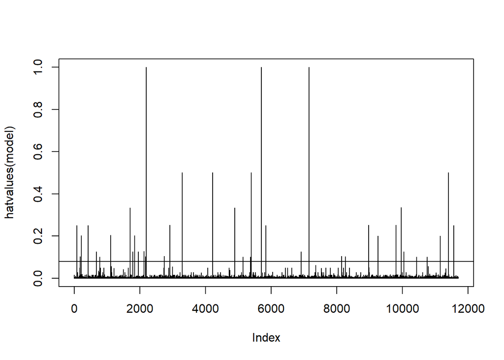

```r
plot(hatvalues(model),type="h"); abline(h=0.08)
```

```r
which(cooks.distance(model)>1)
```

```
## named integer(0)
```

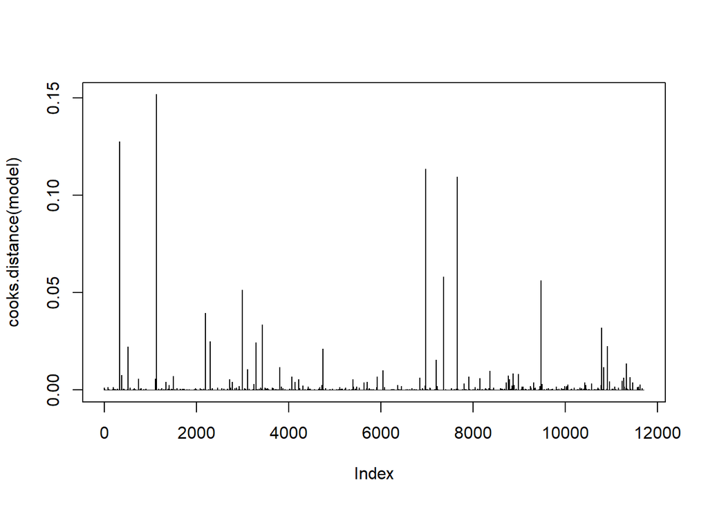

```r
plot(cooks.distance(model),type="h"); abline(h=1)
```

## **DIAGNOSTIC CHECKING**

### **I. NORMALITY**

#### **1. Graphical Analysis of Residuals**

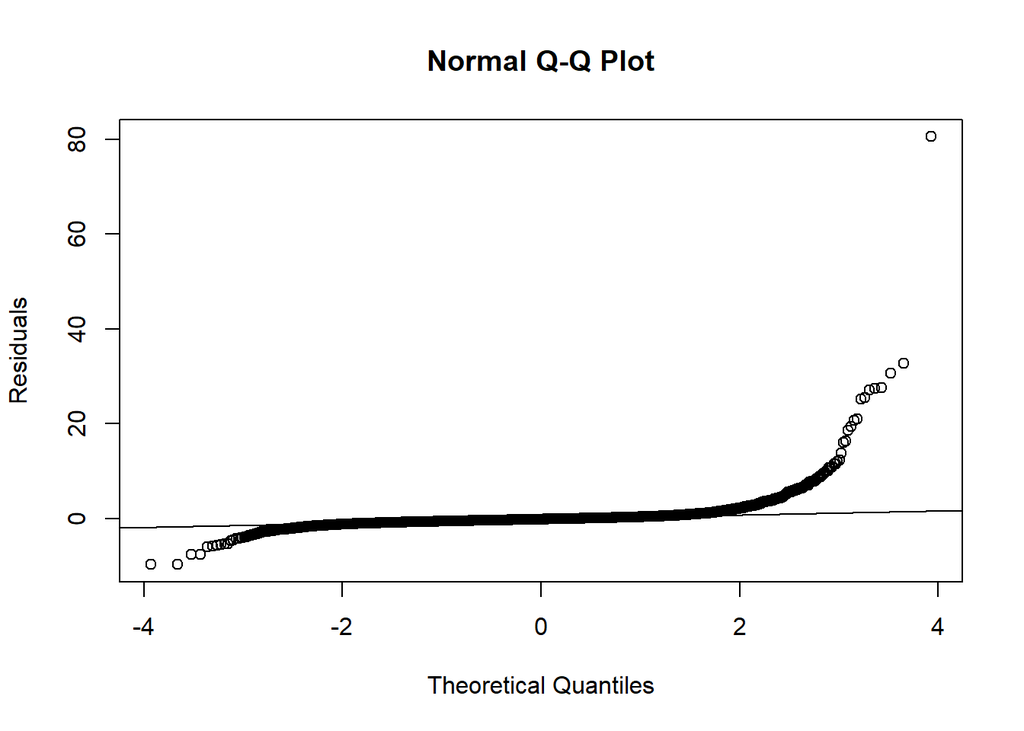

```r
qqnorm(residuals(model), ylab="Residuals")
qqline(residuals(model)) # Normality using Q-Q Plots
```

#### **2. Statistical Test**

**Ho**: ϵ’s normally distributed.

**Ha**: ϵ’s not normally distributed.

##### **2.1. Kolmogorov-Smirnov Test**

```r
resid_std <- scale(residuals(model)) # mean=0, sd=1
ks_test <- ks.test(resid_std, "pnorm") # Kolmogorov-Smirnov Test
ks_test
```

```
##
##  Asymptotic one-sample Kolmogorov-Smirnov test
##
## data:  resid_std
## D = 0.24861, p-value < 2.2e-16
## alternative hypothesis: two-sided
```

We reject the null hypothesis, therefore, **the residuals are not normally distributed.**

### **II. HOMOSCEDASTICITY**

#### **1. Graphical Analysis of Residuals**

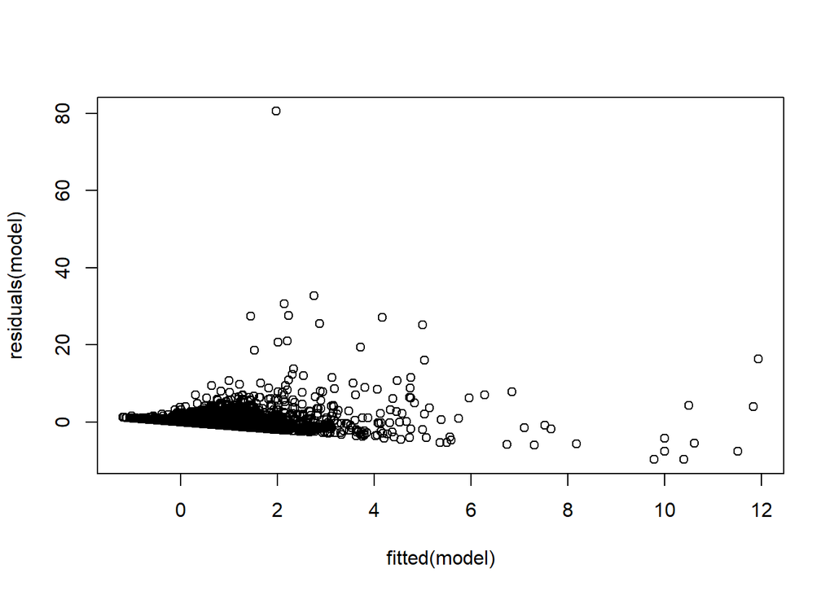

```r
plot(fitted(model), residuals(model))
```

#### **2. Statistical Test**

**Ho**: Heteroscedasticity is not present.

**Ha**: Heteroscedasticity is present.

##### **2.1. Breusch-Pagan-Godfrey Test**

```r
bp_test <- bptest(model) # Breusch-Pagan test
bp_test
```

```
##
##  studentized Breusch-Pagan test
##
## data:  model
## BP = 127.45, df = 53, p-value = 4.502e-08
```

We reject the null hypothesis, therefore, **Heteroscedasticity is present.**

### **III. MULTICOLINEARITY**

#### **1. Statistical Test**

```r
vif_values = vif(model)
vif_values
```

```
##                   GVIF Df GVIF^(1/(2*Df))
## Platform     18.725192 30        1.050043
## Game_Age      7.558729  1        2.749314
## Genre         2.718971 11        1.046515
## Critic_Score  2.096231  1        1.447837
## Critic_Count  1.885766  1        1.373232
## User_Score    1.873463  1        1.368745
## User_Count    1.315425  1        1.146920
## Rating        2.278522  7        1.060588
```

VIF > 5 -> **moderate concern**

VIF > 10 -> **serious multicollinearity**

```
## [1] "Platform is okay (VIF = 1.05 )"
## [1] "Game_Age is okay (VIF = 2.75 )"
## [1] "Genre is okay (VIF = 1.05 )"
## [1] "Critic_Score is okay (VIF = 1.45 )"
## [1] "Critic_Count is okay (VIF = 1.37 )"
## [1] "User_Score is okay (VIF = 1.37 )"
## [1] "User_Count is okay (VIF = 1.15 )"
## [1] "Rating is okay (VIF = 1.06 )"
```

### **IV. INDEPENDENCE**

#### **1. Graphical Analysis of Residuals**

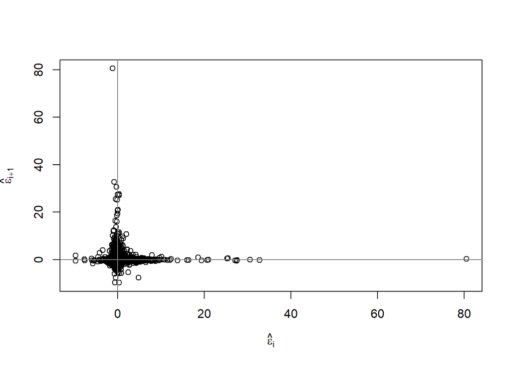

```r
n = length(residuals(model))
plot(tail(residuals(model), n-1) ~
head(residuals(model), n-1),
xlab=expression(hat(epsilon)[i]),
ylab=expression(hat(epsilon)[i+1]))
abline(h=0, v=0, col = grey(0.5))
```

#### **2. Statistical Test**

**Ho**: No auto-correlation (the errors are uncorrelated)

**Ha**: There exists auto-correlation

##### **2.1. Durbin-Watson Test**

```r
dw_test = dwtest(model) # Durbin-Watson Test
dw_test
```

```
##
##  Durbin-Watson test
##
## data:  model
## DW = 2.0191, p-value = 0.8487
## alternative hypothesis: true autocorrelation is greater than 0
```

We fail to reject the null hypothesis, therefore, **there is no auto-correlation.**

## **DATA TRANSFORMATION (Logarithmic Model)**

Since the model is not normally distributed based on the results of the Kolmogorov-Smirnov test, we perform a data transformation using the **Logarithmic Model**.

```r
train.set$Log_Global_Sales <- log(train.set$Global_Sales)

model_log <- lm(Log_Global_Sales ~ Platform + Game_Age + Genre + Critic_Score + Critic_Count + User_Score + User_Count + Rating, data = train.set)

summary(model_log)
```

```
##
## Call:
## lm(formula = Log_Global_Sales ~ Platform + Game_Age + Genre +
##     Critic_Score + Critic_Count + User_Score + User_Count + Rating,
##     data = train.set)
##
## Residuals:
##     Min      1Q  Median      3Q     Max
## -5.4353 -0.8229  0.0281  0.8374  4.6539
##
## Coefficients:
##                     Estimate Std. Error t value Pr(>|t|)
## (Intercept)       -3.105e+00  1.258e+00  -2.469 0.013570 *
## Platform3DO       -1.469e+00  7.287e-01  -2.016 0.043833 *
## Platform3DS        1.141e+00  2.173e-01   5.252 1.53e-07 ***
## PlatformDC         3.726e-01  2.575e-01   1.447 0.147932
## PlatformDS         9.482e-01  1.912e-01   4.959 7.18e-07 ***
## PlatformGB         1.783e+00  2.098e-01   8.498  < 2e-16 ***
## PlatformGBA        7.243e-01  1.782e-01   4.065 4.84e-05 ***
## PlatformGC         6.167e-01  1.820e-01   3.389 0.000704 ***
## PlatformGEN        1.307e-01  3.048e-01   0.429 0.668115
## PlatformGG        -1.609e+00  1.245e+00  -1.292 0.196270
## PlatformN64        8.168e-01  1.772e-01   4.608 4.10e-06 ***
## PlatformNES        1.267e+00  1.963e-01   6.453 1.14e-10 ***
## PlatformNG        -8.226e-01  4.627e-01  -1.778 0.075480 .
## PlatformPC        -1.046e-01  1.982e-01  -0.528 0.597483
## PlatformPCFX      -2.140e+00  1.246e+00  -1.718 0.085845 .
## PlatformPS         9.260e-01  1.602e-01   5.778 7.74e-09 ***
## PlatformPS2        1.154e+00  1.781e-01   6.481 9.46e-11 ***
## PlatformPS3        1.492e+00  2.027e-01   7.361 1.95e-13 ***
## PlatformPS4        1.325e+00  2.284e-01   5.803 6.70e-09 ***
## PlatformPSP        6.864e-01  1.945e-01   3.529 0.000419 ***
## PlatformPSV        6.044e-01  2.232e-01   2.708 0.006774 **
## PlatformSAT       -1.799e-03  1.855e-01  -0.010 0.992263
## PlatformSCD       -7.070e-01  6.350e-01  -1.113 0.265620
## PlatformSNES       5.165e-01  1.730e-01   2.985 0.002842 **
## PlatformTG16      -1.106e+00  8.865e-01  -1.247 0.212311
## PlatformWii        1.503e+00  1.956e-01   7.686 1.64e-14 ***
## PlatformWiiU       1.347e+00  2.420e-01   5.565 2.68e-08 ***
## PlatformWS         2.805e-01  6.395e-01   0.439 0.660880
```

[output cut: 17 more lines]

```
## User_Score        -3.765e-03  1.016e-03  -3.707 0.000211 ***
## User_Count         5.628e-04  3.035e-05  18.543  < 2e-16 ***
## RatingE           -1.503e+00  1.238e+00  -1.214 0.224645
## RatingE10+        -1.555e+00  1.238e+00  -1.256 0.209180
## RatingEC          -1.681e+00  1.298e+00  -1.295 0.195408
## RatingK-A         -2.198e+00  1.516e+00  -1.449 0.147294
## RatingM           -1.620e+00  1.238e+00  -1.309 0.190537
## RatingRP          -2.139e+00  1.356e+00  -1.577 0.114770
## RatingT           -1.670e+00  1.238e+00  -1.349 0.177276
## ---
## Signif. codes:  0 '***' 0.001 '**' 0.01 '*' 0.05 '.' 0.1 ' ' 1
##
## Residual standard error: 1.236 on 11649 degrees of freedom
## Multiple R-squared:  0.2923, Adjusted R-squared:  0.2891
## F-statistic: 90.78 on 53 and 11649 DF,  p-value: < 2.2e-16
```

## **OUTLIERS, LEVERAGE AND INFLUENTIAL POINTS**

```r
which(hatvalues(model_log) > 0.08)
```

```
## 14227  6766 14593 13012 11530  5010 10864 12665  7019 12121 16183 13970 15658
##    86   188   223   424   677   784  1112  1705  1706  1790  1838  1952  2132
## 13263 14637  3263  9010 16686 13491  9225 15563  6048 13457 15636 13573  8296
##  2175  2198  2749  2918  3289  3299  4223  4888  5150  5370  5397  5703  5837
##  7544   876 13067 12525  8041 13674  3927 15079 12825  7588  5035  9203 14273
##  6916  7157  8148  8266  8975  9262  9802  9968 10049 10436 10751 11152 11157
##   904 11783
## 11405 11572
```

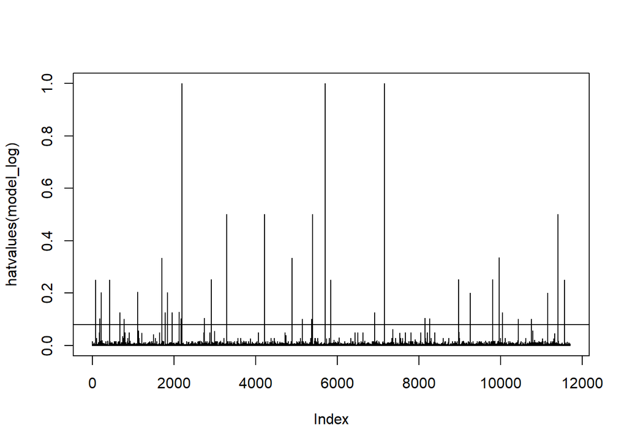

```r
plot(hatvalues(model_log),type="h"); abline(h=0.08)
```

```r
which(cooks.distance(model_log)>1)
```

```
## named integer(0)
```

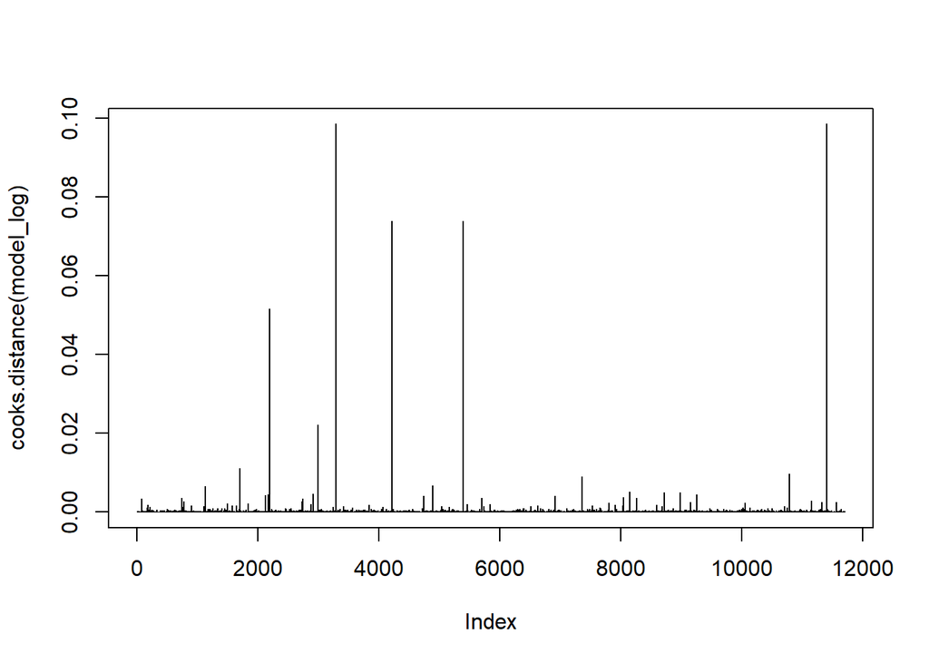

```r
plot(cooks.distance(model_log),type="h"); abline(h=1)
```

## **DIAGNOSTIC CHECKING AFTER DATA TRANSFORMATION**

### **I. NORMALITY**

#### **1. Graphical Analysis of Residuals**

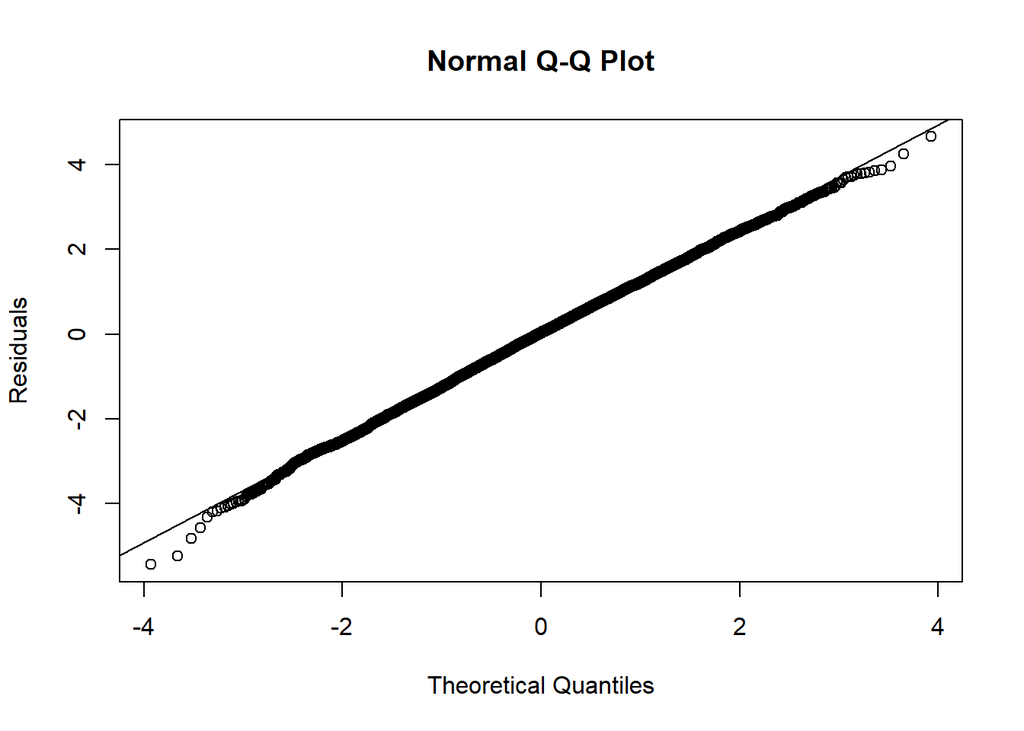

```r
qqnorm(residuals(model_log), ylab="Residuals")
qqline(residuals(model_log)) # Normality using Q-Q Plots
```

#### **2. Statistical Test**

**Ho**: ϵ’s normally distributed.

**Ha**: ϵ’s not normally distributed.

##### **2.1. Kolmogorov-Smirnov Test**

```r
resid_std <- scale(residuals(model_log)) # mean=0, sd=1
ks_test <- ks.test(resid_std, "pnorm") # Kolmogorov-Smirnov Test
ks_test
```

```
##
##  Asymptotic one-sample Kolmogorov-Smirnov test
##
## data:  resid_std
## D = 0.010405, p-value = 0.1586
## alternative hypothesis: two-sided
```

We fail to reject the null hypothesis, therefore, **the residuals are normally distributed.**

### **II. HOMOSCEDASTICITY**

#### **1. Graphical Analysis of Residuals**

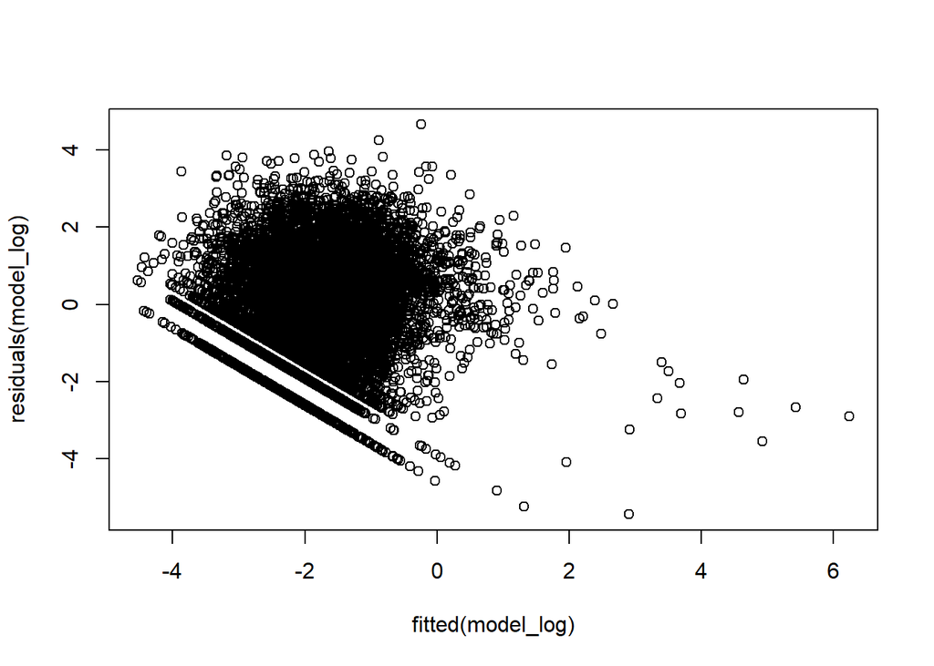

```r
plot(fitted(model_log), residuals(model_log))
```

#### **2. Statistical Test**

**Ho**: Heteroscedasticity is not present.

**Ha**: Heteroscedasticity is present.

##### **2.1. Breusch-Pagan-Godfrey Test**

```r
bp_test <- bptest(model_log) # Breusch-Pagan test
bp_test
```

```
##
##  studentized Breusch-Pagan test
##
## data:  model_log
## BP = 491.24, df = 53, p-value < 2.2e-16
```

We reject the null hypothesis, therefore, **Heteroscedasticity is present.**

### **III. MULTICOLINEARITY**

#### **1. Statistical Test**

```r
vif_values = vif(model_log)
vif_values
```

```
##                   GVIF Df GVIF^(1/(2*Df))
## Platform     18.725192 30        1.050043
## Game_Age      7.558729  1        2.749314
## Genre         2.718971 11        1.046515
## Critic_Score  2.096231  1        1.447837
## Critic_Count  1.885766  1        1.373232
## User_Score    1.873463  1        1.368745
## User_Count    1.315425  1        1.146920
## Rating        2.278522  7        1.060588
```

VIF > 5 -> **moderate concern**

VIF > 10 -> **serious multicollinearity**

```
## [1] "Platform is okay (VIF = 1.05 )"
## [1] "Game_Age is okay (VIF = 2.75 )"
## [1] "Genre is okay (VIF = 1.05 )"
## [1] "Critic_Score is okay (VIF = 1.45 )"
## [1] "Critic_Count is okay (VIF = 1.37 )"
## [1] "User_Score is okay (VIF = 1.37 )"
## [1] "User_Count is okay (VIF = 1.15 )"
## [1] "Rating is okay (VIF = 1.06 )"
```

### **IV. INDEPENDENCE**

#### **1. Graphical Analysis of Residuals**

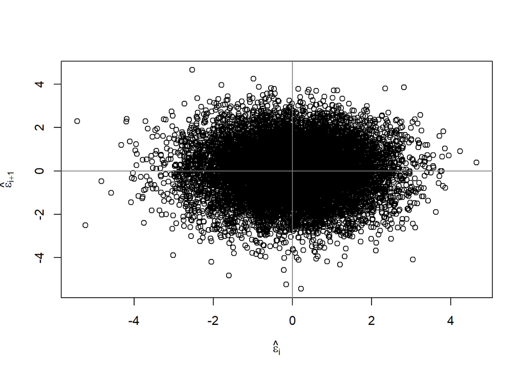

```r
n = length(residuals(model_log))
plot(tail(residuals(model_log), n-1) ~
head(residuals(model_log), n-1),
xlab=expression(hat(epsilon)[i]),
ylab=expression(hat(epsilon)[i+1]))
abline(h=0, v=0, col = grey(0.5))
```

#### **2. Statistical Test**

**Ho**: No auto-correlation (the errors are uncorrelated)

**Ha**: There exists auto-correlation

##### **2.1. Durbin-Watson Test**

```r
dw_test = dwtest(model_log) # Durbin-Watson Test
dw_test
```

```
##
##  Durbin-Watson test
##
## data:  model_log
## DW = 2.019, p-value = 0.8482
## alternative hypothesis: true autocorrelation is greater than 0
```

We fail to reject the null hypothesis, therefore, **there is no auto-correlation.**

## VARIABLE SELECTION

```r
k<-ols_step_best_subset(model_log)
k
```

```
##                                    Best Subsets Regression
## ---------------------------------------------------------------------------------------------
## Model Index    Predictors
## ---------------------------------------------------------------------------------------------
##      1         Platform
##      2         Platform Critic_Count
##      3         Platform Genre Critic_Count
##      4         Platform Genre Critic_Count User_Count
##      5         Platform Genre Critic_Score Critic_Count User_Count
##      6         Platform Game_Age Genre Critic_Score Critic_Count User_Count
##      7         Platform Game_Age Genre Critic_Score Critic_Count User_Count Rating
##      8         Platform Game_Age Genre Critic_Score Critic_Count User_Score User_Count Rating
## ---------------------------------------------------------------------------------------------
##
##                                                         Subsets Regression Summary
## ------------------------------------------------------------------------------------------------------------------------------------------
##                        Adj.        Pred
## Model    R-Square    R-Square    R-Square      C(p)          AIC          SBIC          SBC           MSEP        FPE       HSP      APC
## ------------------------------------------------------------------------------------------------------------------------------------------
##   1        0.1174      0.1151      0.1129    2887.2345    40766.0424    7495.5136    41001.8056    22199.1573    1.9019    2e-04    0.8829
##   2        0.2104      0.2083      0.2061    1357.4816    39464.1492    6193.8569    39707.2800    19860.3347    1.7017    1e-04    0.7900
##   3        0.2392      0.2365      0.2331     906.0251    39051.8542    5761.6464    39376.0286    19138.4668    1.6414    1e-04    0.7613
##   4        0.2626      0.2599      0.2563     522.0075    38687.4367    5397.4013    39018.9788    18550.1164    1.5911    1e-04    0.7380
##   5        0.2772      0.2744       0.271     284.7952    38456.4751    5166.6028    38795.3847    18186.0608    1.5600    1e-04    0.7236
##   6        0.2896      0.2869      0.2835      81.5933    38254.8719    4965.2091    38601.1492    17873.9330    1.5333    1e-04    0.7112
##   7        0.2915      0.2883    -215.9008      65.7401    38238.9540    4937.3339    38636.8044    17829.8224    1.5305    1e-04    0.7095
##   8        0.2923      0.2891        -Inf      54.0000    38227.1583    4925.5664    38632.3763    17810.3398    1.5289    1e-04    0.7088
## ------------------------------------------------------------------------------------------------------------------------------------------
## AIC: Akaike Information Criteria
##  SBIC: Sawa's Bayesian Information Criteria
##  SBC: Schwarz Bayesian Criteria
##  MSEP: Estimated error of prediction, assuming multivariate normality
##  FPE: Final Prediction Error
##  HSP: Hocking's Sp
##  APC: Amemiya Prediction Criteria
```

## 3-FOLD CROSS VALIDATION

```r
# Define training control
train.control <- trainControl(method = "cv", number = 3)

model <- train(log(Global_Sales) ~ Platform + Game_Age + Genre + Critic_Score + Critic_Count + User_Score + User_Count + Rating, data = completed_data, method = "lm", trControl = train.control)

# Summarize the results
print(model)
```

```
## Linear Regression
##
## 16719 samples
##     8 predictor
##
## No pre-processing
## Resampling: Cross-Validated (3 fold)
## Summary of sample sizes: 11146, 11146, 11146
## Resampling results:
##
##   RMSE      Rsquared   MAE
##   1.233837  0.2903431  0.9845908
##
## Tuning parameter 'intercept' was held constant at a value of TRUE
```